# R for EPP research Assignment 3

Angelos-Miltiadis Krypotos

2016-03-15

## How to complete the assignment.

Please write your answers below each question, indicating clearly to which question (or subquestion) your answer refers to. I would prefer if you would send your answers as an html document using “knitr” and with all the code having been already executed. You can create html documents in R studio by just clicking the notepad icon on the top – For more info how to create notebooks in R studio see [here](https://support.rstudio.com/hc/en-us/articles/200552276-Creating-Notebooks-from-R-Scripts). If you want, you can also send your answers as an .R script. Lastly, writing your assignments in .doc or .docx is also OK, but because of automatised formatting etc., it would be hard for me to check whether the code is running properly or not.

## Exercise 1

Check the links below for more information on implicit looping in R. - [Apply family](https://www.datacamp.com/community/tutorials/r-tutorial-apply-family)

This is a nice article, but quite advanced [The Split-Apply-Combine Strategy for Data Analysis](https://www.jstatsoft.org/article/view/v040i01).

## Answer 1

Done.

## Exercise 2

There are so many tutorials on plots out there. Indeed it looks like everyone who has just a simple idea about R, has to write a tutorial. Here is a list that you may want to check:

- http://www.harding.edu/fmccown/r/
- http://www.r-tutor.com/elementary-statistics/qualitative-data/bar-graph
- http://www.r-tutor.com/elementary-statistics/quantitative-data/scatter-plot
- https://flowingdata.com/2012/12/17/getting-started-with-charts-in-r/

A few years ago, I even wrote a tutorial [here](https://github.com/AngelosPsy/AtinyIntroductionOnGraphsWithR/releases). Please do not read it – it is crap – but you can check the ‘Tips and Tricks’ chapter at the end.

## Answer 2

Done.

## Exercise 3

Run the code below. eval = FALSE

```r
x <- data.frame(ID = paste0("Part_", 1:2000), CS = 1:10, USExp = runif(2000, -5, 5))
```

Compute, seperately, the mean and standard error (check the package plotrix for that) for every CS.

## Answer 3

```r
library(plotrix)
x <- data.frame(ID = paste0("Part_", 1:2000), CS = 1:10, USExp = runif(2000, -5, 5))
tapply(x$USExp, x$CS, mean)
```

```
##            1            2            3            4            5
##  0.215536655 -0.203200809  0.211181332 -0.190762879 -0.177300139
##            6            7            8            9           10
## -0.108694091  0.125226816  0.063522635  0.062369945  0.003747053
```

```r
tapply(x$USExp, x$CS, std.error)
```

```
##         1         2         3         4         5         6         7
## 0.1959309 0.1925619 0.2085727 0.1983637 0.1966913 0.2188704 0.2033029
##         8         9        10
## 0.2078922 0.2023323 0.1947919
```

## Exercise 4

Run the code below eval = FALSE

```r
my.list <- list(Group = rep(1:2, each = 100), EMG1 = rnorm (200, 500, 50), EMG2 = rnorm (200, 480, 40))
```

1. Convert the object above to a data frame

## Answer 4a

```r
my.list <- list(Group = rep(1:2, each = 100), EMG1 = rnorm (200, 500, 50), EMG2 = rnorm (200, 480, 40))
my.df <- data.frame(my.list)
```

2. Create a new column named “EMGDiff”. Compute the difference between EMG1 and EMG2 *for* every participants using a function from the apply family [Please note, that you could use vectorization or an explicit loop here. The point of this excercise, thought, is that you gain a bit of experience with implicit looping]. Fill in the column EMDiff with the values you have computed.

## Answer 4b

```r
my.df$EMDiff <- apply(my.df[, 2:3], 1, diff)
```

3. Compute the log of EMG1 and EMG2 (?log). By using a function from the apply family, compute the median of the logarithm of EMG1 and EMG2 – not for EMGDiff.

Answer 4c

```r
apply(log(my.df[, 2:3]), 2, median)
```

```
##     EMG1     EMG2
## 6.203700 6.174152
```

OR – Although we have not seen this in class

```r
apply(my.df[, 2:3], 2, function(x) median(log(x)))
```

```
##     EMG1     EMG2
## 6.203700 6.174152
```

Exercise 5 This exercise is based on parts of exercise 7 of the previous assignment. First, run the code below eval = FALSE

```r
my.data.list <- list()
for (i in 1:100){
  my.data.list[[i]] <- c(NA, rnorm(10000, mean = 600, sd = 50))
}
```

1. Using a function from the apply family, first center (?scale) all values from all list elements. Save that new list into the object *my.data.list.center*.

Answer 5a

```r
my.data.list.center <- lapply(my.data.list, scale, scale = FALSE)
```

2. Compute the mean of each list element of the my.data.list.center (hint: you may want to check the mean function if you want to deal with NAs).

Answer 5b

```r
mean.list <- lapply(my.data.list.center, mean, na.rm = T)
```

## Exercise 6

Plot the means of the CSs that you computed at exercise 3 as a barplot. Make sure that - Every bar should have a different color - the names should be on the bottom of each plot - The label on the y axis should read “CS Mean”.

## Answer 6

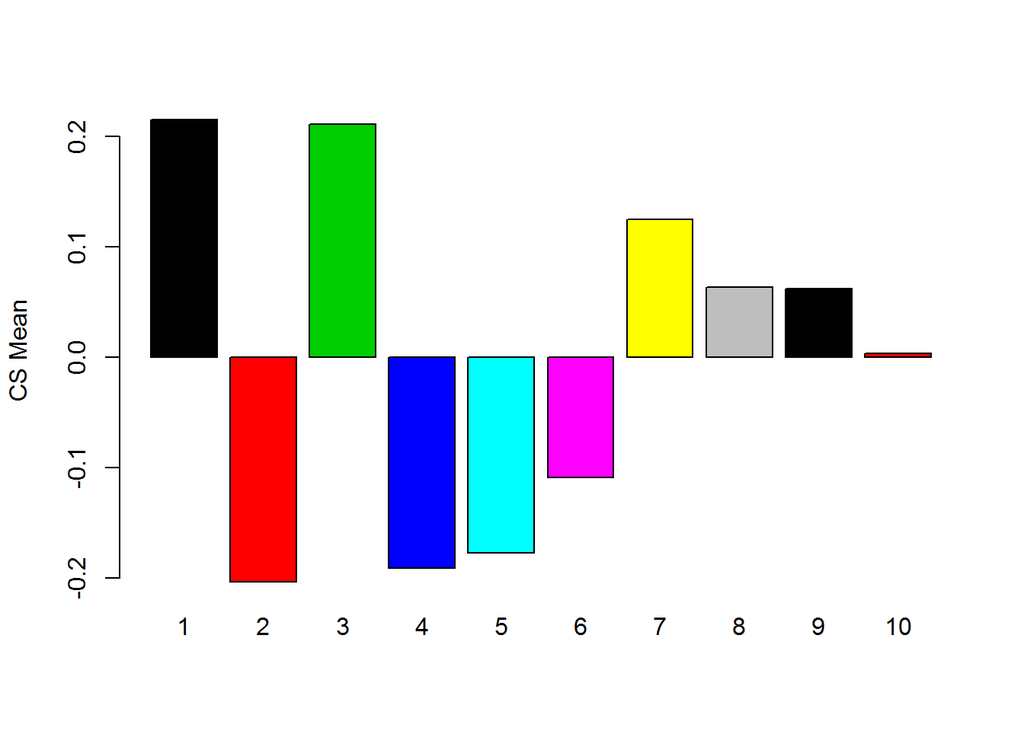

```r
barz <- tapply(x$USExp, x$CS, mean)
barplot(barz, col = 1:10, names.arg = 1:10, ylab = "CS Mean")
```

```r
x <- c(0, 0, NA, 0, 1, 2, 3, 4, 5, NA, 5, 4, 3, 2, -1, -5)
y <- c(0, 0, NA, 0, -1, -2, -3, -4, -5, NA, -5, -5, -5, -5, -5, -5)
```

With these data, make the plot that you can see on that [link](https://www.dropbox.com/s/fdsthlzfw5rmwko/plotGraph.png?dl=0). If you find it difficult, you can always check the hints document, that has step to step hints. But maybe first try to see how far you can go on your own.

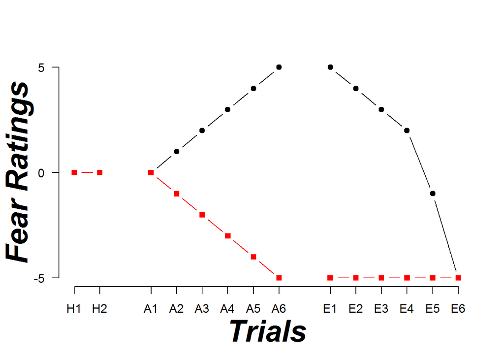

```r
plot(x, type = "b", pch = 19, xlab = "", ylab = "", axes = FALSE)
points(y, type = "b", col = "red", pch = 15)
axis(1, c(1:2, 4:9, 11:16), paste0(rep(c("H", "A", "E"), c(2, 6, 6)), c(1:2, 1:6, 1:6)))
axis(2, c(-5, 0, 5), c(-5, 0, 5), las = 1)
graphics::mtext("Fear Ratings", 2, font = 4, cex = 2.5, line = 2)
graphics::mtext("Trials", 1, font = 4, cex = 2.5, line = 3)
```